# data_science_task_adrian_liu

```python
# Import Libraries
import pandas as pd
import numpy as np
import seaborn as sns
import openpyxl
from openpyxl import load_workbook
import matplotlib.pyplot as plt
plt.rcParams['figure.figsize'] = [15, 10]
```

### Data Description

https://digital.nhs.uk/data-and-information/publications/statistical/quality-and-outcomes-framework-achievement-prevalence-and-exceptions-data/2019-20 https://qof.digital.nhs.uk/

**Table 3: Prevalence, achievement and personalised care adjustments, cardiovascular group, cardiovascular disease – primary prevention, 2019-20, GP practice level**

#### Definitions

*Following definitions have been taken from the resource links above.*

- Prevalence: A measure of the frequency of a disease of health condition
- Achievement: The QOF gives an indication of the overall achievement of a practice through a points system. Reference to 100 per cent achievement often refers to the percentage of available QOF points achieved.
- Exceptions: Exception reporting’ refers to the potential removal of these patients from calculations of practice achievement for specific clinical indicators.
- Personalised Care Adjustment (PCA): As of 1 April 2019, exception reporting was replaced with Personalised Care Adjustments (PCAs). Unlike exception reporting, PCAs are extracted in the same order for all indicators, enabling more robust insight to be gained from their analysis.
- CVDPP001: In those patients with a new diagnosis of hypertension aged 30 or over and who have not attained the age of 75, recorded between the preceding 1 April to 31 March (excluding those with pre-existing CHD, diabetes, stroke and/or TIA), who have a recorded CVD risk assessment score (using an assessment tool agreed with the NHS CB) of ≥20% in the preceding 12 months: the percentage who are currently treated with statins.

```python
'''
Store suffix for prevalence and achievement columns.
'''
prev_cols = ['List size 30-74', 'Register', 'Prevalence (%)']
achieve_cols = ['Total Achievement Score (max 10 per practice)', 'Achievement (%)']
```

### Reading data to Pandas DataFrame

A pandas dataframe will be our preferred data structure, and to convert from our existing Excel Worksheet structure I require some wrangling/formatting.

1. Parsing of header
2. Selecting slice of worksheet which contains corresponding data

```python
wb = load_workbook('data/qof-1920-prev-ach-pca-cv-prac.xlsx')
ws = wb['CVD-PP']
```

```python
'''
Parsing of the header.
Header spans three rows of the worksheet
Header contains merged rows on row 12
'''
ws['A12'] = None # remove 'Return to Contents' link from header row
header_cols = []
init_col = ''
for cells in zip(ws[12], ws[13], ws[14]):
    if cells[0].value:
        init_col = col = str(cells[0].value)
    elif type(cells[0]) is openpyxl.cell.cell.MergedCell:
        col = init_col
    else:
        col = ''
    for cell in [cells[1], cells[2]]:
        val = cell.value
        if val:
            col += str(val)
    header_cols.append(col)
```

```python
'''
Obtaining worksheet slice for dataframe data structure conversion.
'''
ws.delete_rows(6735, ws.max_row) # delete empty rows at end of file
ws.delete_rows(0, 14) # delete header rows
data = ws.values
df = pd.DataFrame(ws.values, columns=header_cols) # dataframe conversion
```

```python
'''
Add complete column name for "Year on year change".
'''
cols = list(df.columns)
cols[13] = 'Prevelance Year on year change (percentage point)'
cols[18] = 'Achievement Year on year change (percentage point)'
cols[25] = 'PCA Achievement Year on year change (percentage point)'
df.columns = cols
```

### Data Quality Checks

- Check column types
- Check we have unique Practice Code for each row, possibly handle and duplicates
- Summarize data with display of noteable properties and statistics

Below I notice that some columns which should be numeric, such as `2018-19List size ages 30-74` have an object dtype.

Checking the non-numeric values from some of these columns we have only ':'. I assume ':' is used for missing values.

dtypes are now suitable with replacement with np.nan.

```python
'''
Check that for each row we have unique 'Practice code'. Or possible any other primary key.
'''
# i.e. that we have a unique key for each row
unique_counts = df['Practice code'].unique()
assert len(unique_counts) == df.shape[0], 'number of unique "Practice code" is not equal to data frame length'
```

```python
'''
Store previous dtypes
'''
before = df.dtypes
```

```python
'''
Check non-numeric values for columns which should be only numeric.
'''
non_numeric = set()
cols_to_check = ['2018-19Register', '2018-19List size ages 30-74', '2018-19Prevalence (%)']
for col in cols_to_check:
    for val in df[col]:
        if not (isinstance(val, int) or isinstance(val, float)):
            non_numeric.add(val)
'Non-numeric values: {}'.format(non_numeric)
```

```
"Non-numeric values: {':'}"
```

```python
'''
Create dataframe of column properties
'''
df = df.replace(':', np.nan)
na_count = df.isna().sum()
df_properties = pd.DataFrame({'dtypes_before': before, 'dtypes_after': df.dtypes, 'na_count': na_count, 'na_count_percentage': na_count/df.shape[0]})
```

```python
def summarise_col(col):
    '''
    Returns a summary stats for a pandas series
    '''
    nunique = col.nunique()
    if col.dtype != 'O':
        mean = col.mean()
        std = col.std()
        min_ = col.min()
        max_ = col.max()
        return nunique, mean, std, min_, max_
    else:
        return nunique, np.nan, np.nan, np.nan, np.nan
```

```python
'''
Display relavent properties and stats for each column
'''
df_summary = df.apply(summarise_col, axis=0).transpose()
df_summary.columns = ['nunique', 'mean', 'std', 'min', 'max']
pd.concat([df_properties, df_summary], axis=1)
```

|  | dtypes_before | dtypes_after | na_count | na_count_percentage | nunique | mean | std | min | max |
| --- | --- | --- | --- | --- | --- | --- | --- | --- | --- |
| CCG ODS code (practice parent) | object | object | 0 | 0.000000 | 135.0 | NaN | NaN | NaN | NaN |
| CCG ONS code (practice parent) | object | object | 0 | 0.000000 | 135.0 | NaN | NaN | NaN | NaN |
| CCG name (practice parent) | object | object | 0 | 0.000000 | 135.0 | NaN | NaN | NaN | NaN |
| PCN ODS code | object | object | 0 | 0.000000 | 1251.0 | NaN | NaN | NaN | NaN |
| PCN name | object | object | 0 | 0.000000 | 1251.0 | NaN | NaN | NaN | NaN |
| Practice code | object | object | 0 | 0.000000 | 6720.0 | NaN | NaN | NaN | NaN |
| Practice name | object | object | 0 | 0.000000 | 6353.0 | NaN | NaN | NaN | NaN |
| 2018-19List size ages 30-74 | object | float64 | 56 | 0.008333 | 4639.0 | 4896.033914 | 3066.981719 | 9.000000 | 42983.000000 |
| 2018-19Register | object | float64 | 56 | 0.008333 | 259.0 | 55.576681 | 43.615292 | 0.000000 | 754.000000 |
| 2018-19Prevalence (%) | object | float64 | 56 | 0.008333 | 6343.0 | 1.143762 | 0.605595 | 0.000000 | 22.222222 |
| 2019-20List size ages 30-74 | int64 | int64 | 0 | 0.000000 | 4751.0 | 5039.005804 | 3232.146169 | 10.000000 | 47196.000000 |
| 2019-20Register | int64 | int64 | 0 | 0.000000 | 269.0 | 59.884673 | 46.477343 | 0.000000 | 636.000000 |
| 2019-20Prevalence (%) | float64 | float64 | 0 | 0.000000 | 6382.0 | 1.202833 | 0.684465 | 0.000000 | 28.571429 |
| Prevelance Year on year change (percentage point) | object | float64 | 56 | 0.008333 | 6654.0 | 0.058788 | 0.643809 | -14.529915 | 27.817524 |
| 2018-19Total Achievement Score (max 10 per practice) | object | float64 | 56 | 0.008333 | 29.0 | 9.128622 | 2.708823 | 0.000000 | 10.000000 |
| 2018-19Achievement (%) | object | float64 | 56 | 0.008333 | 29.0 | 91.286224 | 27.088235 | 0.000000 | 100.000000 |
| 2019-20Total Achievement Score (max 10 per practice) | float64 | float64 | 0 | 0.000000 | 36.0 | 8.804193 | 3.074645 | 0.000000 | 10.000000 |
| 2019-20Achievement (%) | float64 | float64 | 0 | 0.000000 | 36.0 | 88.041935 | 30.746446 | 0.000000 | 100.000000 |
| Achievement Year on year change (percentage point) | object | float64 | 56 | 0.008333 | 86.0 | -3.132698 | 34.189747 | -100.000000 | 100.000000 |
| 2018-19Total Exceptions | object | float64 | 71 | 0.010565 | 21.0 | 1.460220 | 1.932282 | 0.000000 | 29.000000 |
| 2018-19Total Denominators | object | float64 | 56 | 0.008333 | 30.0 | 2.994598 | 2.786080 | 0.000000 | 35.000000 |
| 2018-19Overall Exception Rate (%) | object | float64 | 366 | 0.054464 | 117.0 | 26.971996 | 25.897515 | 0.000000 | 100.000000 |
| 2019-20Total PCAs | int64 | int64 | 0 | 0.000000 | 21.0 | 1.502976 | 1.953772 | 0.000000 | 25.000000 |
| 2019-20Total Denominators | int64 | int64 | 0 | 0.000000 | 34.0 | 3.279613 | 3.209127 | 0.000000 | 56.000000 |
| 2019-20Overall PCA Rate (%) | object | float64 | 367 | 0.054613 | 122.0 | 27.153217 | 26.070367 | 0.000000 | 100.000000 |
| PCA Achievement Year on year change (percentage point) | object | object | 0 | 0.000000 | 1.0 | NaN | NaN | NaN | NaN |
| CVDPP001Achievement Score (max 10 per practice) | float64 | float64 | 0 | 0.000000 | 36.0 | 8.804193 | 3.074645 | 0.000000 | 10.000000 |
| CVDPP001Numerator | int64 | int64 | 0 | 0.000000 | 31.0 | 3.127827 | 2.989519 | 0.000000 | 35.000000 |
| CVDPP001Denominator | int64 | int64 | 0 | 0.000000 | 34.0 | 3.279613 | 3.209127 | 0.000000 | 56.000000 |
| CVDPP001Underlying Achievement net of PCAs (%) | object | float64 | 524 | 0.077976 | 60.0 | 96.159463 | 14.603513 | 0.000000 | 100.000000 |
| CVDPP001PCAs | int64 | int64 | 0 | 0.000000 | 21.0 | 1.502976 | 1.953772 | 0.000000 | 25.000000 |
| CVDPP001PCA Rate (%) | object | float64 | 367 | 0.054613 | 122.0 | 27.153217 | 26.070367 | 0.000000 | 100.000000 |
| CVDPP001Denominator plus PCAs | int64 | int64 | 0 | 0.000000 | 41.0 | 4.782589 | 4.484322 | 0.000000 | 57.000000 |
| CVDPP001Patients receiving Intervention (%) | object | float64 | 367 | 0.054613 | 130.0 | 69.872700 | 27.326031 | 0.000000 | 100.000000 |

```python
df = df.drop(columns=['CCG ONS code (practice parent)',
                 'CCG name (practice parent)',
                 'PCN name', 'Practice name',
                 'PCA Achievement Year on year change (percentage point)'])
```

```python
'''
Print of dataframe for final sanity check.
'''
pd.set_option('display.max_columns', df.shape[1])
print(df.head())
```

```
  CCG ODS code (practice parent) PCN ODS code Practice code  \
0                            00L       U25545        A84006
1                            00L       U11112        A84005
2                            00L       U25545        A84008
3                            00L       U05512        A84027
4                            00L       U05512        A84047

   2018-19List size ages 30-74  2018-19Register  2018-19Prevalence (%)  \
0                      11069.0            148.0               1.337067
1                       6766.0             53.0               0.783328
2                       2832.0             26.0               0.918079
3                       2107.0             29.0               1.376364
4                       3339.0             30.0               0.898473

   2019-20List size ages 30-74  2019-20Register  2019-20Prevalence (%)  \
```

[output cut: 89 more lines]

The data is now cleaned for use within an EDA. We notice:

- Each line is for each Practice and Practices can be grouped into Primary Care Networks (PCNs) and Clinical Commissioning Groups (CCGs).
- We have separate columns for 2018-2019 and 2019-2020.
- Exceptions in 2018-2019 get changed to PCAs in 2019-2020.
- 'Total Achievement Score (max 10 per practice)' and 'Achievement (%)' are equivalent and one of columns can be dropped for further analysis.

```python
'''
Drop 'Total Achievement Score' columns.
'''
df = df.drop(columns=['2018-19Total Achievement Score (max 10 per practice)', '2019-20Total Achievement Score (max 10 per practice)'])
```

### Exploratory Data Analysis

First we look at some correlations, mainly we can look at Prevalence, Achievement and Exclusions/PCA across 2018-19, 2019-20 and CVDPP001.

```python
def corr_plot(df):
    '''
    Creates a heatmap for a correlation matrix for a visual representation
    of correlation matrix.
    '''
    corr = df.corr()
    mask = np.triu(np.ones_like(corr, dtype=bool))
    cmap = sns.diverging_palette(200, 0, as_cmap=True)
    plot = sns.heatmap(corr,
                      mask=mask,
                      cmap=cmap,
                      vmax=1,
                      center=0,
                      square=True,
                      linewidths=1)
    annot_plot = sns.heatmap(corr[(corr >= 0.5) | (corr <= -0.5)],
                      mask=mask,
                      cmap=cmap,
                      vmax=1,
                      center=0,
                      square=True,
                      linewidths=1,
                      annot=True,
                      cbar=False)
    return corr, plot, annot_plot
```

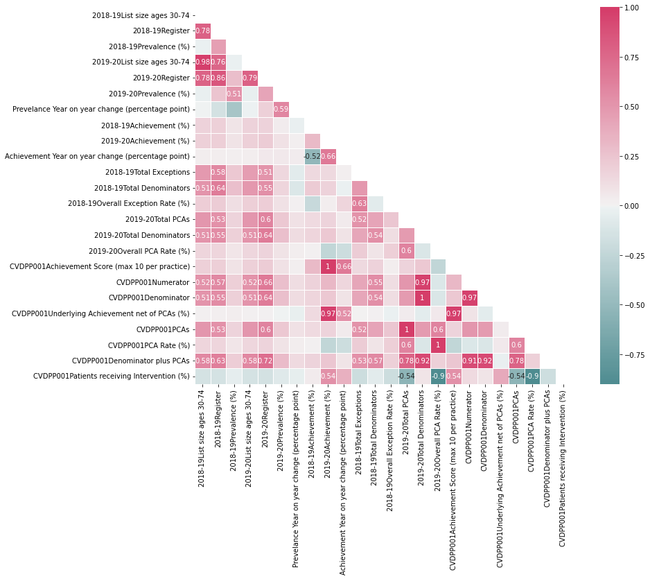

```python
_, plot, annot_plot = corr_plot(df.iloc[:, 3:])
plot;
annot_plot;
```

We can notice:

- High Positive correlation with CVDPP001 Achievement and Underlying Achievement net of PCAs with 2019-20 Achievement. Similarly with Denominators.
  - NOTE: CVDPP001PCA Rate and 2019-2020Overall PCA Rate, CVDPP001PCAs and 2019-20Total PCAs, CVDPP001Denominator and 2019-20Total Denominations, CVDPP001Achievement Score and 2019-20Achievement variable pairings have all correlation of 1 and thus we can omit redundent columns.
- Negative correlation with CVDPP001 Patients receiving Intervention and PCA Rates and Total PCAs, but not as much with Exceptions.
- General Positive correlations with many variables which may indicate multicollinearity we might be vary of if used in predictive models.
- We may expect that Overall Exception Rate and Total Exceptions would have a higher correlation.

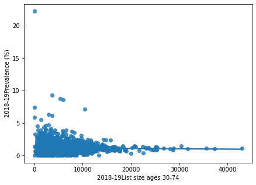

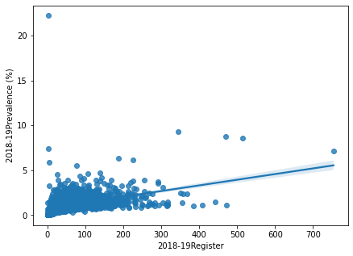

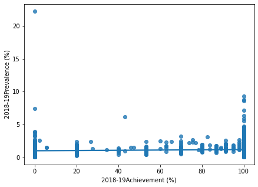

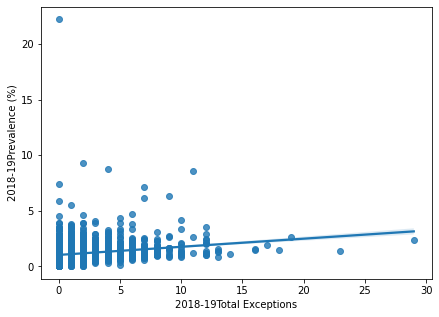

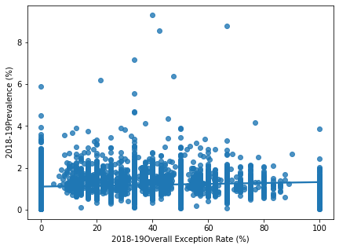

```python
plt.rcParams['figure.figsize'] = [7, 5]
for col in ['2018-19List size ages 30-74', '2018-19Register', '2018-19Achievement (%)', '2018-19Total Exceptions', '2018-19Overall Exception Rate (%)']:
    sns.regplot(x=col, y='2018-19Prevalence (%)', data=df)
    plt.show()
```

Looking more detailed with fitting a linear model against Prevalance we see that the some slight positive correlations in general likely come from the increases in population with Register and Total Exceptions. Although doesn't follow with Achievement score or Overall Exception rate which are wonderfully uncorrelated.

If more time available it may be worth also comparing other combinations of variables, also creating multivariate regression models testing for multicollinearity.

```python
'''
As mentioned above, dropping redundant columns.
'''
drop_columns = ['CVDPP001PCAs', 'CVDPP001PCA Rate (%)', 'CVDPP001Denominator', 'CVDPP001Achievement Score (max 10 per practice)']
df = df.drop(columns=drop_columns)
```

#### Numerical Distriubtions

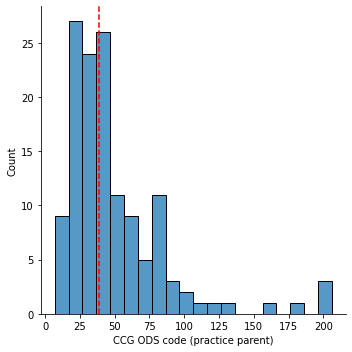

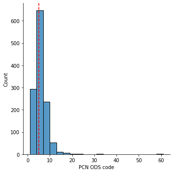

```python
'''
Plotting distribution histograms of practice counts by CCG and PCN with median line.
'''
sns.displot(df['CCG ODS code (practice parent)'].value_counts(), bins=20);
plt.axvline(np.median(df['CCG ODS code (practice parent)'].value_counts()),color='r', linestyle='--');
sns.displot(df['PCN ODS code'].value_counts(), bins=20);
plt.axvline(np.median(df['PCN ODS code'].value_counts()),color='r', linestyle='--');
```

Plotting histograms of practice counts for CCGs and PCNs, we see that we have tailed distributions for both. This may be interesting when compared against aggregated stats for other variables.

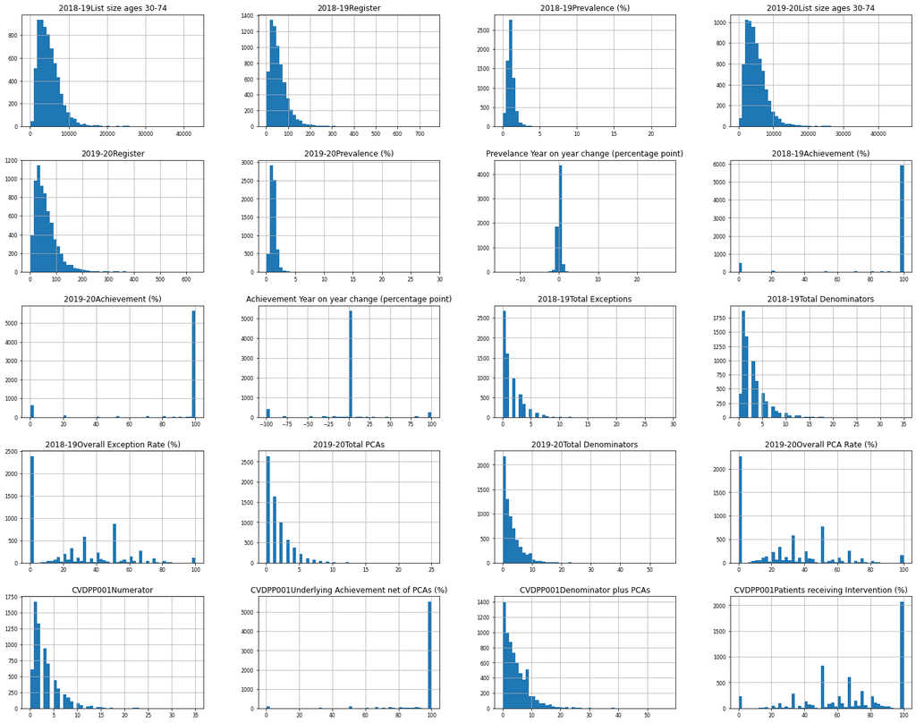

```python
'''
Histograms of numeric variables.
'''
df.iloc[:, 3:].hist(figsize=(25, 20), bins=50, xlabelsize=8, ylabelsize=8);
```

- We see similar to log-normal distributions for List size, Register, and Prevalence.
- Achievement percent is often 100.
- Prevelence and Achievement change year on year is mostly 0 indicating mostly no change.

With SME knowledge we may be able to see any non-intuitive or interesting patterns.

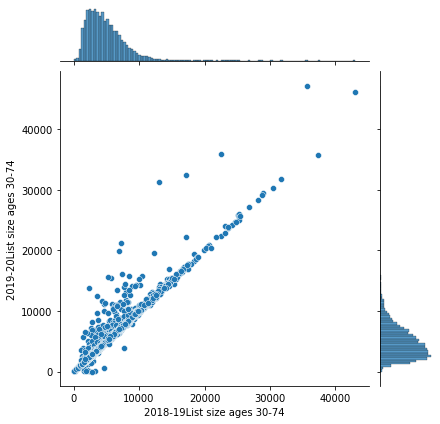

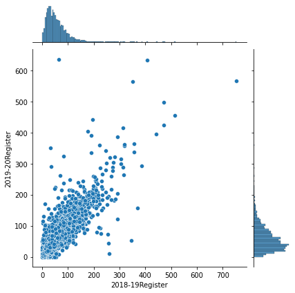

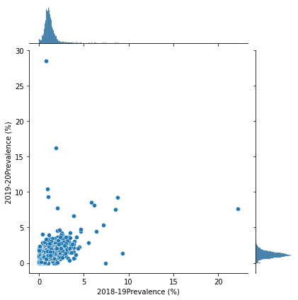

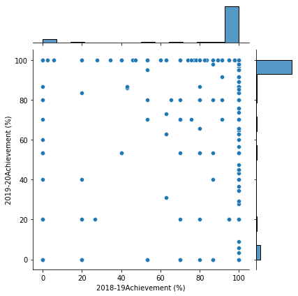

```python
'''
Pairplots comparing 2018-19 and 2019-20
'''
variables = ['List size ages 30-74', 'Register', 'Prevalence (%)', 'Achievement (%)']
for var in variables:
    sns.jointplot(data=df,
                  x='2018-19{}'.format(var),
                  y='2019-20{}'.format(var))
```

Comparing List size, Register, Prevalence and Achievement between 2018-19 and 2019-20 we see distributions are very similar, and Register and List size will some larger values for 2019-20 which makes intuitve sense as population continually increases.

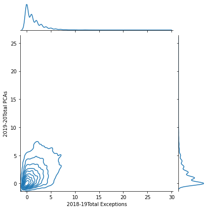

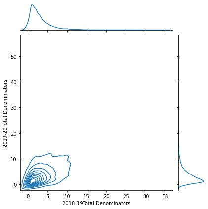

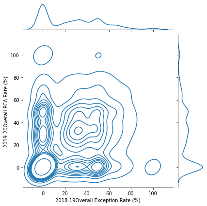

```python
'''
Pairplots comparing exceptions 2018-19 and PCAs 2019-20
'''
ex_variables = ['2018-19Total Exceptions', '2018-19Total Denominators', '2018-19Overall Exception Rate (%)']
pca_variables = ['2019-20Total PCAs', '2019-20Total Denominators', '2019-20Overall PCA Rate (%)']
for ex_var, pca_var in zip(ex_variables, pca_variables):
    sns.jointplot(data=df,
                  x=ex_var,
                  y=pca_var,
                  kind='kde')
```

As protocol has changed from 2018-19 to 2019-20 for reporting Exceptions as PCAs now, it may be interesting to compare distributions of alternative equivalents. We can notice that even with this change the distribution for totals and rate are very similar.

### Clustering

```python
from sklearn.cluster import KMeans
from sklearn.impute import SimpleImputer
from sklearn.preprocessing import scale
```

```python
'''
Extracting numeric data and scaling.
'''
X = df.iloc[:, 3:]
scaled_X = X.copy()
scaled_X[:] = scale(X)
```

```python
'''
Impute missing values with median.
'''
imputer = SimpleImputer(missing_values=np.nan, strategy='median')
scaled_X[:] = imputer.fit_transform(scaled_X)
```

```python
'''
Fit kmeans model.
'''
kmeans = KMeans(n_clusters=8)
kmeans.fit(scaled_X)
```

```
KMeans()
```

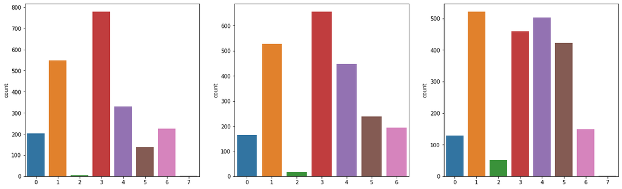

```python
'''
Bar plots of counts of clusters splitting by PCN code counts.
'''
col = 'PCN ODS code'
_counts = df[col].value_counts()
_cumsum = _counts.cumsum()
third, two_third = len(_cumsum[_cumsum < int(_cumsum[-1] * (1/3))]),  len(_cumsum[_cumsum < int(_cumsum[-1] * (2/3))])

plt.rcParams['figure.figsize'] = [20, 6]
fig, ax =plt.subplots(1,3)
predicted = kmeans.predict(scaled_X[df[col].isin(_counts.index[0:third])])
sns.countplot(x=predicted, ax=ax[0]);
predicted = kmeans.predict(scaled_X[df[col].isin(_counts.index[third + 1:two_third])])
sns.countplot(x=predicted, ax=ax[1]);
predicted = kmeans.predict(scaled_X[df[col].isin(_counts.index[two_third + 1:_cumsum[-1]])])
sns.countplot(x=predicted, ax=ax[2]);
fig.show()
```

Looking ath the cluster distribution against low, medium and high counts of patients in PCNs we crealy see some different distributions. This indicates that we can have latent space or reduce the dimensionality while we still can explain our data.

If I had more time it would be interesting to try similarly against other variables. And other clustering techniques, it can be seen here that sizes of clusters are also not of equal size.

### Dimensionality Reduction (Principal Component Analysis)

As seen above dimensionality reduction may be able to explain our data with reducing complexity.

```python
from sklearn.decomposition import PCA
```

```python
'''
Fitting PCA model and transforming our data.
'''
n_components=X.shape[1]
pca = PCA(n_components=n_components)
pca.fit(scaled_X)
X_pca = pca.transform(scaled_X)
```

```
              Variance Explained
N components
1                       0.350493
2                       0.484925
3                       0.575876
4                       0.663128
5                       0.741370
6                       0.808537
7                       0.861791
8                       0.911547
9                       0.940188
10                      0.967484
11                      0.979477
12                      0.986459
13                      0.992683
14                      0.996608
15                      0.998053
16                      0.999074
17                      0.999472
18                      0.999842
19                      1.000000
20                      1.000000
```

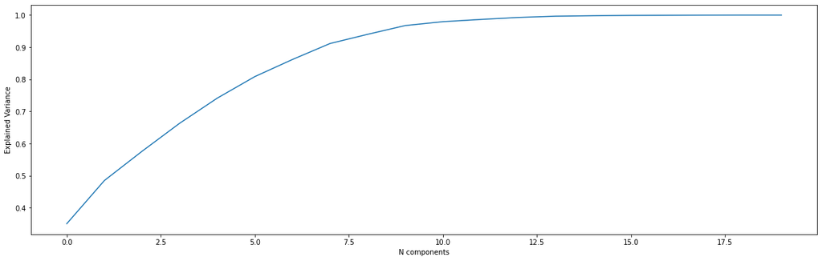

```python
'''
Printing and plotting variance explained against number of principal components.
'''
var_explained = pd.DataFrame({'Variance Explained':pca.explained_variance_ratio_.cumsum()})
var_explained.index = np.array(var_explained.index) + 1
var_explained.index.names = ['N components']
print(var_explained)
pca_df = pd.DataFrame({'Explained Variance':pca.explained_variance_ratio_.cumsum(), 'N components': range(0, pca.n_components)})
sns.lineplot(x='N components', y='Explained Variance', data=pca_df);
```

We that the first 9 principal components are able to explain 94% of the variance in our dataset, allowing for a reduction of 11 features. Benefits from dimensionality reduction include:

- Reducing affects of curse of dimensionality
- Reducing size and processing load
- Removal of some multicollinearity, improving interpretation of features for ML purposes.

```python
'''
Fitting PCA model with 2 principal components.
'''
n_components=2
pca = PCA(n_components=n_components)
pca.fit(scaled_X)
X_pca = pca.transform(scaled_X)
var_explained = pd.DataFrame({'Variance Explained':pca.explained_variance_ratio_.cumsum()})
var_explained.index = np.array(var_explained.index) + 1
var_explained.index.names = ['N components']
print(var_explained)
```

```
              Variance Explained
N components
1                       0.350493
2                       0.484925
```

```
2018-19Register
```

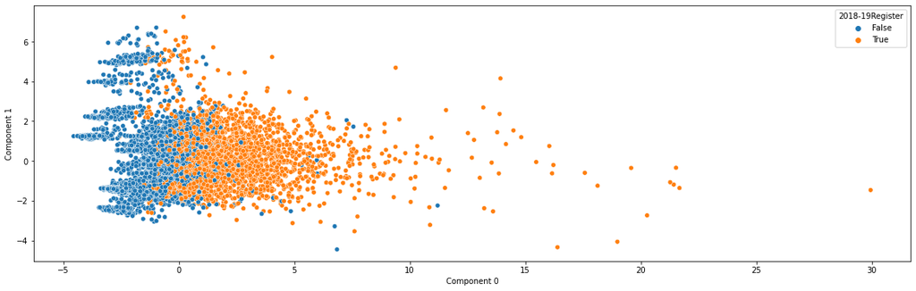

```python
col = '2018-19Register'
print(col)
prev_large = scaled_X[col] > scaled_X[col].mean() # create binary indicator for when '2018-19Register' larger than mean
sns.scatterplot(x=X_pca[:, 0], y=X_pca[:, 1], hue=prev_large).set(xlabel='Component 0', ylabel='Component 1');
```

```
2018-19Achievement (%)
```

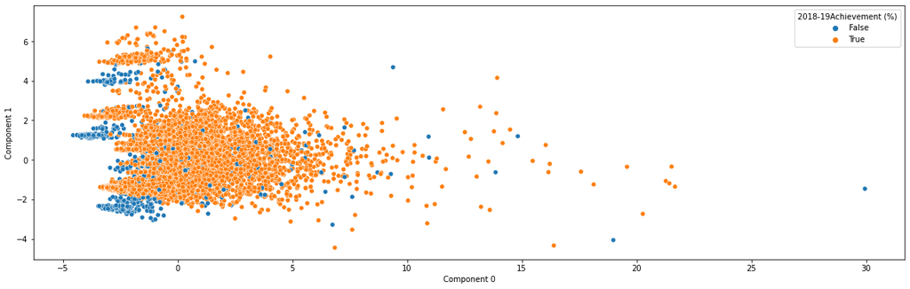

```python
col = '2018-19Achievement (%)'
print(col)
prev_large = scaled_X[col] > scaled_X[col].mean() # create binary indicator for when '2018-19Register' larger than mean
sns.scatterplot(x=X_pca[:, 0], y=X_pca[:, 1], hue=prev_large).set(xlabel='Component 0', ylabel='Component 1');
```

Fitting the PCA with a limit of only 2 components we see that only %48 of the variance is explained. But with the lower dimension representation we are able to easily visualise, as above with the 2D scatterplot.

In this plot I colour the points for when '2018-19Register' is larger than mean to Orange, equal and less to Blue. In our case we see a clear pattern of positive relationship will '2018-19Register' and 'Component 0' showing it as an important feature to explain to data. Plotting similarly with '2018-19Achievement (%)' we see less of a pattern.

If more time available plotting a 3D scatterplot and exploring patterns with other features may be interesting.

### Conclusions

Our data is sourced from NHS digital Quality of Outcomes Framework (QOF), and is a worksheet containing the prevalence, achievement and PCAs for cardiovascular disease. Each line contains the results for a practice and each practice belongs to groups CCGs and PCNs.

For use in analysis we first required some work for parsing correctly the data, selecting data rows and parsing header, as data is in Excel worksheet format. We also note ':' and 'z' being used for missing or not available data.

We see correlations with all '2018-19', '2019-20' and 'CVDPP001' of respective columns and thus dived a bit further with exploring clustering and dimensionality reduction. We notice when varying 'PCN ODS code' cluster predictions change. With '2018-19Register' we notice a pattern within principal components. Also we clearly can benefit from dimension reduction as PCA can explain 94% of the data's variance with while reducing from 20 to 9 features. *If more time available encoding the 'CCG ODS code' and 'PCN ODS code' together with the clustering and dimension reduction analysis may give us further insight, and discover more patterns.*

We discover some patterns within our data already, if other datasets containing CCG, PCN or Practice codes we also have opportunity to aggregate and join for further analysis.